# K-means clustering for time-series data

## Consdering stimulus-cluster relationships

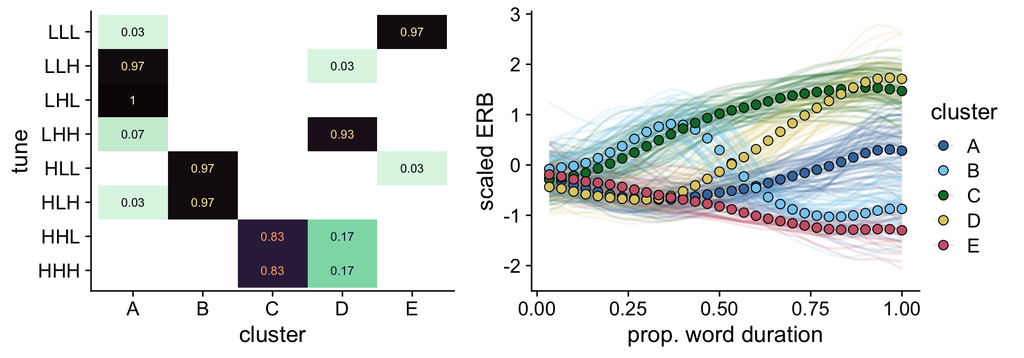

## Other clustering solutions

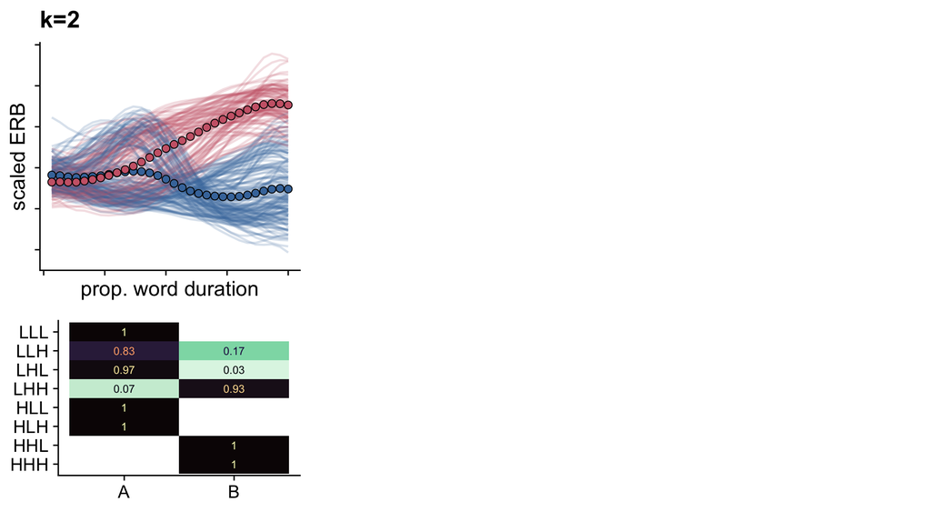

## Other clustering solutions

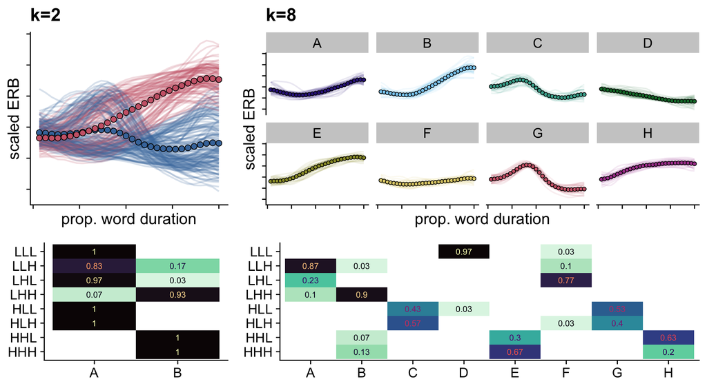

## Individual variation

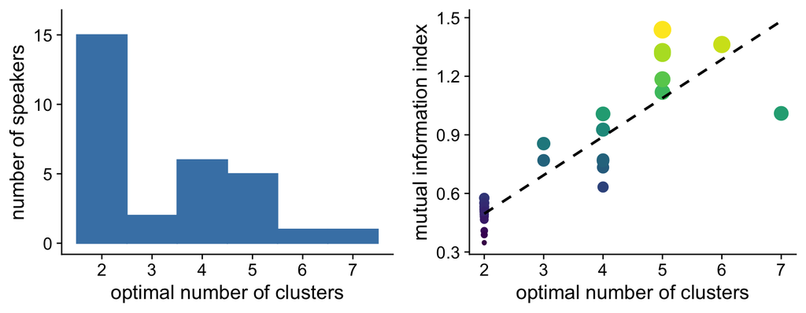

#### Individual speaker clustering solutions can become the object of analysis

- Potentially related to group or individual characteristics
- At left, a histogram showing variation in terms of optimal k
- At right, the relationship between this number and mutual information: i.e. the predictive strength of the relationship between stimulus tunes and clusters

## Individual variation

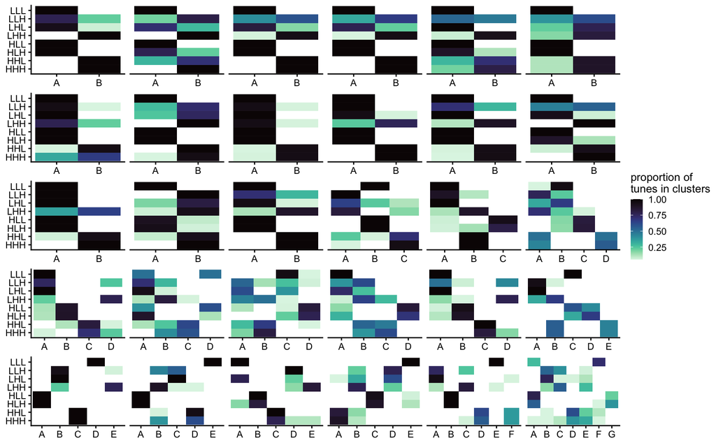

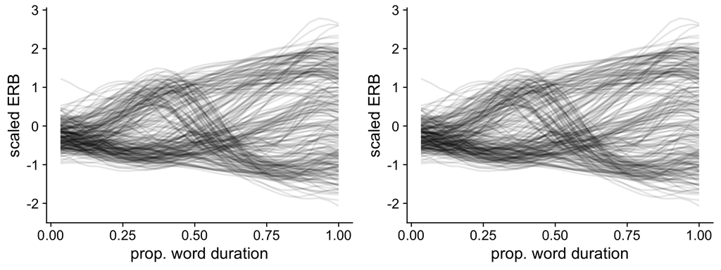

## Concluding remarks

### K-means offers a fairly intuitive way of assessing groupings in data

- And is easily implemented for time series data
- Tests of different numbers of k can be interweaved with domain knowledge or predictions
- Robust to outliers, easy to test with a range of k values

### There are however, crucial considerations

- Unlike hierarchical clustering, for which a single dendrogram can be “cut” in different locations to yield different numbers of clusters, k-means offers many possible solutions based on the range of k’s tested
- This makes k selection, and optimization a crucial part of the k-means workflow
- This can happen all “under the hood” in R, with various degrees of researcher intervention
- Other considerations are shared between the methods: normalisation/scaling, distance measures, etc.

## Concluding remarks

### K-means offers a fairly intuitive way of assessing groupings in data

- And is easily implemented for time series data
- Tests of different numbers of k can be interweaved with domain knowledge or predictions
- Robust to outliers, easy to test with a range of k values

### There are however, crucial considerations

- Unlike hierarchical clustering, for which a single dendrogram can be “cut” in different locations to yield different numbers of clusters, k-means offers many possible solutions based on the range of k’s tested
- This makes k selection, and optimization a crucial part of the k-means workflow
- This can happen all “under the hood” in R, with various degrees of researcher intervention
- Other considerations are shared between the methods: normalisation/scaling, distance measures, etc.